# ASSIGNMENT 4

NAME : HANSINI JYOTHIRMAYI VADDEY

REDG NO: 21BDS0345

Question: 1.Download the Employee Attrition Dataset https://www.kaggle.com/datasets/patelprashant/employee-attrition 2.Perfrom Data Preprocessing 3.Model Building using Logistic Regression and Decision Tree and Random forest 4.Calculate Performance metrics

# DATA PREPROCESSING

Steps 1.import necessary libraries

2.import dataset

3.Handling null values

4.Data Visualization

5.Outlier detection

6.Seperate dependent and independent variables

7.Encoding

8.Splitting into training set and testing set

9.Feature Scaling

## 1.Import necessary libraries

```python
import numpy as np
```

```python
import pandas as pd
```

```python
import matplotlib.pyplot as plt
```

```python
import seaborn as sns
```

## 2.Load the Dataset

```python
dataset=pd.read_csv("HR-Employee-Attrition.csv")
```

```python
dataset
```

|  | Age | Attrition | BusinessTravel | DailyRate | Department | DistanceFromHome | Education | EducationField | EmployeeCount | EmployeeNumber | ... | RelationshipSatisfaction | StandardHours | StockOptionLevel | TotalWorkingYears | TrainingTimesLastYear | WorkLifeBalance | YearsAtCompany | YearsInCurrentRole | YearsSinceLastPromotion | YearsWithCurrManager |
| --- | --- | --- | --- | --- | --- | --- | --- | --- | --- | --- | --- | --- | --- | --- | --- | --- | --- | --- | --- | --- | --- |
| 0 | 41 | Yes | Travel_Rarely | 1102 | Sales | 1 | 2 | Life Sciences | 1 | 1 | ... | 1 | 80 | 0 | 8 | 0 | 1 | 6 | 4 | 0 | 5 |
| 1 | 49 | No | Travel_Frequently | 279 | Research & Development | 8 | 1 | Life Sciences | 1 | 2 | ... | 4 | 80 | 1 | 10 | 3 | 3 | 10 | 7 | 1 | 7 |
| 2 | 37 | Yes | Travel_Rarely | 1373 | Research & Development | 2 | 2 | Other | 1 | 4 | ... | 2 | 80 | 0 | 7 | 3 | 3 | 0 | 0 | 0 | 0 |
| 3 | 33 | No | Travel_Frequently | 1392 | Research & Development | 3 | 4 | Life Sciences | 1 | 5 | ... | 3 | 80 | 0 | 8 | 3 | 3 | 8 | 7 | 3 | 0 |
| 4 | 27 | No | Travel_Rarely | 591 | Research & Development | 2 | 1 | Medical | 1 | 7 | ... | 4 | 80 | 1 | 6 | 3 | 3 | 2 | 2 | 2 | 2 |
| ... | ... | ... | ... | ... | ... | ... | ... | ... | ... | ... | ... | ... | ... | ... | ... | ... | ... | ... | ... | ... | ... |
| 1465 | 36 | No | Travel_Frequently | 884 | Research & Development | 23 | 2 | Medical | 1 | 2061 | ... | 3 | 80 | 1 | 17 | 3 | 3 | 5 | 2 | 0 | 3 |
| 1466 | 39 | No | Travel_Rarely | 613 | Research & Development | 6 | 1 | Medical | 1 | 2062 | ... | 1 | 80 | 1 | 9 | 5 | 3 | 7 | 7 | 1 | 7 |
| 1467 | 27 | No | Travel_Rarely | 155 | Research & Development | 4 | 3 | Life Sciences | 1 | 2064 | ... | 2 | 80 | 1 | 6 | 0 | 3 | 6 | 2 | 0 | 3 |
| 1468 | 49 | No | Travel_Frequently | 1023 | Sales | 2 | 3 | Medical | 1 | 2065 | ... | 4 | 80 | 0 | 17 | 3 | 2 | 9 | 6 | 0 | 8 |
| 1469 | 34 | No | Travel_Rarely | 628 | Research & Development | 8 | 3 | Medical | 1 | 2068 | ... | 1 | 80 | 0 | 6 | 3 | 4 | 4 | 3 | 1 | 2 |

1470 rows × 35 columns

```python
dataset.head()
```

|  | Age | Attrition | BusinessTravel | DailyRate | Department | DistanceFromHome | Education | EducationField | EmployeeCount | EmployeeNumber | ... | RelationshipSatisfaction | StandardHours | StockOptionLevel | TotalWorkingYears | TrainingTimesLastYear | WorkLifeBalance | YearsAtCompany | YearsInCurrentRole | YearsSinceLastPromotion | YearsWithCurrManager |
| --- | --- | --- | --- | --- | --- | --- | --- | --- | --- | --- | --- | --- | --- | --- | --- | --- | --- | --- | --- | --- | --- |
| 0 | 41 | Yes | Travel_Rarely | 1102 | Sales | 1 | 2 | Life Sciences | 1 | 1 | ... | 1 | 80 | 0 | 8 | 0 | 1 | 6 | 4 | 0 | 5 |
| 1 | 49 | No | Travel_Frequently | 279 | Research & Development | 8 | 1 | Life Sciences | 1 | 2 | ... | 4 | 80 | 1 | 10 | 3 | 3 | 10 | 7 | 1 | 7 |
| 2 | 37 | Yes | Travel_Rarely | 1373 | Research & Development | 2 | 2 | Other | 1 | 4 | ... | 2 | 80 | 0 | 7 | 3 | 3 | 0 | 0 | 0 | 0 |
| 3 | 33 | No | Travel_Frequently | 1392 | Research & Development | 3 | 4 | Life Sciences | 1 | 5 | ... | 3 | 80 | 0 | 8 | 3 | 3 | 8 | 7 | 3 | 0 |
| 4 | 27 | No | Travel_Rarely | 591 | Research & Development | 2 | 1 | Medical | 1 | 7 | ... | 4 | 80 | 1 | 6 | 3 | 3 | 2 | 2 | 2 | 2 |

5 rows × 35 columns

```python
dataset.info()
```

```
<class 'pandas.core.frame.DataFrame'>
RangeIndex: 1470 entries, 0 to 1469
Data columns (total 35 columns):
 #   Column                    Non-Null Count  Dtype
---  ------                    --------------  -----
 0   Age                       1470 non-null   int64
 1   Attrition                 1470 non-null   object
 2   BusinessTravel            1470 non-null   object
 3   DailyRate                 1470 non-null   int64
 4   Department                1470 non-null   object
 5   DistanceFromHome          1470 non-null   int64
 6   Education                 1470 non-null   int64
 7   EducationField            1470 non-null   object
 8   EmployeeCount             1470 non-null   int64
 9   EmployeeNumber            1470 non-null   int64
```

[output cut: 27 more lines]

```python
dataset.shape
```

```
(1470, 35)
```

```python
dataset.describe()
```

|  | Age | DailyRate | DistanceFromHome | Education | EmployeeCount | EmployeeNumber | EnvironmentSatisfaction | HourlyRate | JobInvolvement | JobLevel | ... | RelationshipSatisfaction | StandardHours | StockOptionLevel | TotalWorkingYears | TrainingTimesLastYear | WorkLifeBalance | YearsAtCompany | YearsInCurrentRole | YearsSinceLastPromotion | YearsWithCurrManager |
| --- | --- | --- | --- | --- | --- | --- | --- | --- | --- | --- | --- | --- | --- | --- | --- | --- | --- | --- | --- | --- | --- |
| count | 1470.000000 | 1470.000000 | 1470.000000 | 1470.000000 | 1470.0 | 1470.000000 | 1470.000000 | 1470.000000 | 1470.000000 | 1470.000000 | ... | 1470.000000 | 1470.0 | 1470.000000 | 1470.000000 | 1470.000000 | 1470.000000 | 1470.000000 | 1470.000000 | 1470.000000 | 1470.000000 |
| mean | 36.923810 | 802.485714 | 9.192517 | 2.912925 | 1.0 | 1024.865306 | 2.721769 | 65.891156 | 2.729932 | 2.063946 | ... | 2.712245 | 80.0 | 0.793878 | 11.279592 | 2.799320 | 2.761224 | 7.008163 | 4.229252 | 2.187755 | 4.123129 |
| std | 9.135373 | 403.509100 | 8.106864 | 1.024165 | 0.0 | 602.024335 | 1.093082 | 20.329428 | 0.711561 | 1.106940 | ... | 1.081209 | 0.0 | 0.852077 | 7.780782 | 1.289271 | 0.706476 | 6.126525 | 3.623137 | 3.222430 | 3.568136 |
| min | 18.000000 | 102.000000 | 1.000000 | 1.000000 | 1.0 | 1.000000 | 1.000000 | 30.000000 | 1.000000 | 1.000000 | ... | 1.000000 | 80.0 | 0.000000 | 0.000000 | 0.000000 | 1.000000 | 0.000000 | 0.000000 | 0.000000 | 0.000000 |
| 25% | 30.000000 | 465.000000 | 2.000000 | 2.000000 | 1.0 | 491.250000 | 2.000000 | 48.000000 | 2.000000 | 1.000000 | ... | 2.000000 | 80.0 | 0.000000 | 6.000000 | 2.000000 | 2.000000 | 3.000000 | 2.000000 | 0.000000 | 2.000000 |
| 50% | 36.000000 | 802.000000 | 7.000000 | 3.000000 | 1.0 | 1020.500000 | 3.000000 | 66.000000 | 3.000000 | 2.000000 | ... | 3.000000 | 80.0 | 1.000000 | 10.000000 | 3.000000 | 3.000000 | 5.000000 | 3.000000 | 1.000000 | 3.000000 |
| 75% | 43.000000 | 1157.000000 | 14.000000 | 4.000000 | 1.0 | 1555.750000 | 4.000000 | 83.750000 | 3.000000 | 3.000000 | ... | 4.000000 | 80.0 | 1.000000 | 15.000000 | 3.000000 | 3.000000 | 9.000000 | 7.000000 | 3.000000 | 7.000000 |
| max | 60.000000 | 1499.000000 | 29.000000 | 5.000000 | 1.0 | 2068.000000 | 4.000000 | 100.000000 | 4.000000 | 5.000000 | ... | 4.000000 | 80.0 | 3.000000 | 40.000000 | 6.000000 | 4.000000 | 40.000000 | 18.000000 | 15.000000 | 17.000000 |

8 rows × 26 columns

```python
dataset.Age.value_counts()
```

```
35    78
34    77
36    69
31    69
29    68
32    61
30    60
33    58
38    58
40    57
37    50
27    48
28    48
42    46
39    42
```

[output cut: 29 more lines]

```python
dataset.DailyRate.value_counts()
```

```
691     6
408     5
530     5
1329    5
1082    5
       ..
650     1
279     1
316     1
314     1
628     1
Name: DailyRate, Length: 886, dtype: int64
```

## 3.Handling Null values

```python
dataset.isnull().any()
```

```
Age                         False
Attrition                   False
BusinessTravel              False
DailyRate                   False
Department                  False
DistanceFromHome            False
Education                   False
EducationField              False
EmployeeCount               False
EmployeeNumber              False
EnvironmentSatisfaction     False
Gender                      False
HourlyRate                  False
JobInvolvement              False
JobLevel                    False
JobRole                     False
JobSatisfaction             False
MaritalStatus               False
MonthlyIncome               False
MonthlyRate                 False
NumCompaniesWorked          False
Over18                      False
OverTime                    False
PercentSalaryHike           False
PerformanceRating           False
RelationshipSatisfaction    False
StandardHours               False
StockOptionLevel            False
TotalWorkingYears           False
TrainingTimesLastYear       False
WorkLifeBalance             False
YearsAtCompany              False
YearsInCurrentRole          False
YearsSinceLastPromotion     False
YearsWithCurrManager        False
dtype: bool
```

No null values present

```python
dataset.isnull().sum()
```

```
Age                         0
Attrition                   0
BusinessTravel              0
DailyRate                   0
Department                  0
DistanceFromHome            0
Education                   0
EducationField              0
EmployeeCount               0
EmployeeNumber              0
EnvironmentSatisfaction     0
Gender                      0
HourlyRate                  0
JobInvolvement              0
JobLevel                    0
JobRole                     0
JobSatisfaction             0
MaritalStatus               0
MonthlyIncome               0
MonthlyRate                 0
NumCompaniesWorked          0
Over18                      0
OverTime                    0
PercentSalaryHike           0
PerformanceRating           0
RelationshipSatisfaction    0
StandardHours               0
StockOptionLevel            0
TotalWorkingYears           0
TrainingTimesLastYear       0
WorkLifeBalance             0
YearsAtCompany              0
YearsInCurrentRole          0
YearsSinceLastPromotion     0
YearsWithCurrManager        0
dtype: int64
```

## 4.Data Visualization

```python
dataset
```

|  | Age | Attrition | BusinessTravel | DailyRate | Department | DistanceFromHome | Education | EducationField | EmployeeCount | EmployeeNumber | ... | RelationshipSatisfaction | StandardHours | StockOptionLevel | TotalWorkingYears | TrainingTimesLastYear | WorkLifeBalance | YearsAtCompany | YearsInCurrentRole | YearsSinceLastPromotion | YearsWithCurrManager |
| --- | --- | --- | --- | --- | --- | --- | --- | --- | --- | --- | --- | --- | --- | --- | --- | --- | --- | --- | --- | --- | --- |
| 0 | 41 | Yes | Travel_Rarely | 1102 | Sales | 1 | 2 | Life Sciences | 1 | 1 | ... | 1 | 80 | 0 | 8 | 0 | 1 | 6 | 4 | 0 | 5 |
| 1 | 49 | No | Travel_Frequently | 279 | Research & Development | 8 | 1 | Life Sciences | 1 | 2 | ... | 4 | 80 | 1 | 10 | 3 | 3 | 10 | 7 | 1 | 7 |
| 2 | 37 | Yes | Travel_Rarely | 1373 | Research & Development | 2 | 2 | Other | 1 | 4 | ... | 2 | 80 | 0 | 7 | 3 | 3 | 0 | 0 | 0 | 0 |
| 3 | 33 | No | Travel_Frequently | 1392 | Research & Development | 3 | 4 | Life Sciences | 1 | 5 | ... | 3 | 80 | 0 | 8 | 3 | 3 | 8 | 7 | 3 | 0 |
| 4 | 27 | No | Travel_Rarely | 591 | Research & Development | 2 | 1 | Medical | 1 | 7 | ... | 4 | 80 | 1 | 6 | 3 | 3 | 2 | 2 | 2 | 2 |
| ... | ... | ... | ... | ... | ... | ... | ... | ... | ... | ... | ... | ... | ... | ... | ... | ... | ... | ... | ... | ... | ... |
| 1465 | 36 | No | Travel_Frequently | 884 | Research & Development | 23 | 2 | Medical | 1 | 2061 | ... | 3 | 80 | 1 | 17 | 3 | 3 | 5 | 2 | 0 | 3 |
| 1466 | 39 | No | Travel_Rarely | 613 | Research & Development | 6 | 1 | Medical | 1 | 2062 | ... | 1 | 80 | 1 | 9 | 5 | 3 | 7 | 7 | 1 | 7 |
| 1467 | 27 | No | Travel_Rarely | 155 | Research & Development | 4 | 3 | Life Sciences | 1 | 2064 | ... | 2 | 80 | 1 | 6 | 0 | 3 | 6 | 2 | 0 | 3 |
| 1468 | 49 | No | Travel_Frequently | 1023 | Sales | 2 | 3 | Medical | 1 | 2065 | ... | 4 | 80 | 0 | 17 | 3 | 2 | 9 | 6 | 0 | 8 |
| 1469 | 34 | No | Travel_Rarely | 628 | Research & Development | 8 | 3 | Medical | 1 | 2068 | ... | 1 | 80 | 0 | 6 | 3 | 4 | 4 | 3 | 1 | 2 |

1470 rows × 35 columns

### i) Scatter plot

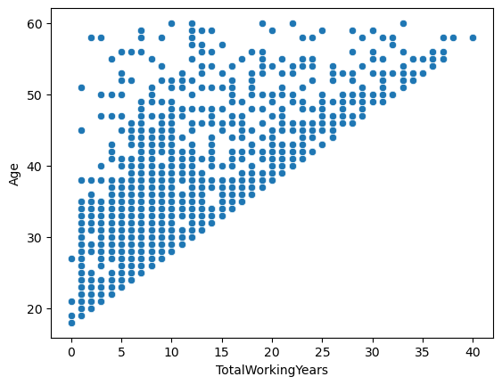

```python
sns.scatterplot(x="TotalWorkingYears",y="Age",data=dataset)
```

Inference: The scatterplot comparing "TotalWorkingYears" on the x-axis and "Age" on the y-axis using the data from the dataset.this scatterplot confirms the expected positive correlation between total working years and age, but it also highlights the presence of outliers and individual variations within the dataset.

### ii)Line Plot

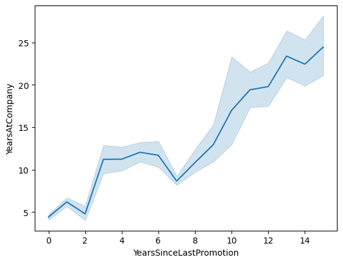

```python
sns.lineplot(x="YearsSinceLastPromotion",y="YearsAtCompany",data=dataset)
```

### iii)Distribution plot

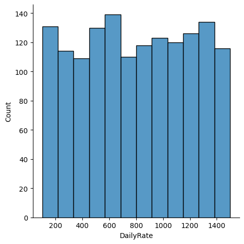

```python
sns.displot(dataset["DailyRate"])
```

Inference : This is a distribution plot (histogram) of the "DailyRate" variable from your dataset using Seaborn.seful for understanding the distribution of daily rates and identifying any patterns or irregularities in the data

### iv)Relational Plot

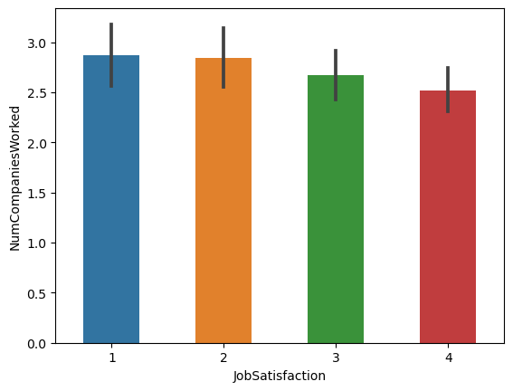

```python
sns.barplot(data=dataset, x="JobSatisfaction", y="NumCompaniesWorked", width=0.5)
```

Inference : This Bar plot shows the relationship between job satisfaction and the number of companies worked for in your dataset.: The x-axis represents different levels of job satisfaction, and the y-axis represents the average or aggregated number of companies employees have worked for ("NumCompaniesWorked") for each level of job satisfaction.

### v)Joint Plot

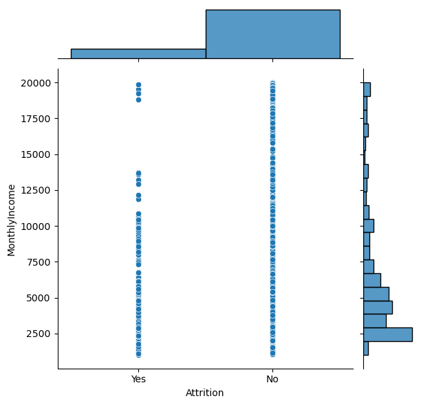

```python
sns.jointplot(x="Attrition",y="MonthlyIncome",data=dataset)
```

Inference : This joint plot provides a visual representation of the relationship between attrition and monthly income in your dataset.The central part of the joint plot is a scatter plot. In this case, "Attrition" is on the x-axis (usually a categorical variable), and "MonthlyIncome" is on the y-axis (a continuous variable). Each point on the scatter plot represents an employee's monthly income, and its position on the x-axis is determined by their attrition status. he marginal histograms on the top and right sides provide insights into the individual distributions of each variable.It helps assess whether there's a correlation between the two variables

### vi)Box Plot

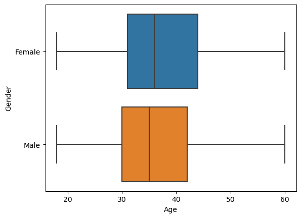

```python
sns.boxplot(x="Age",y="Gender",data=dataset)
```

Inference : This box plot visualizes and compare the distribution of ages within different gender categories in your dataset. It provides insights into the central tendency, spread, and potential outliers in the age data for each gender group, facilitating a better understanding of how age varies by gender in your dataset.

### Heatmap

Correlation before Encoding

```python
corr=dataset.corr() #As Data visualization step in the question is given before encoding we are getting warning message.
```

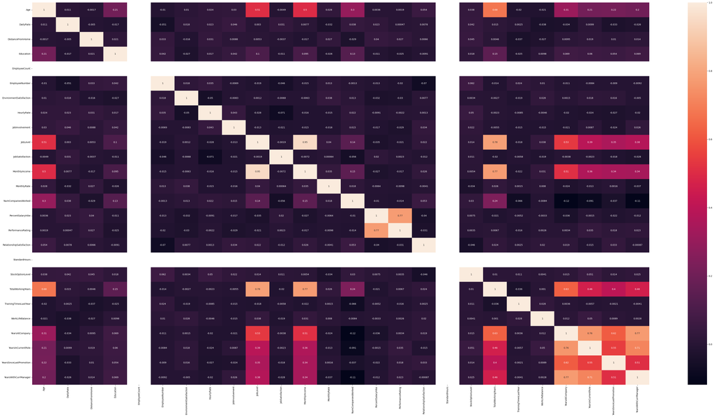

```python
plt.subplots(figsize=(60,30))
sns.heatmap(corr,annot=True)
```

Inference : This heatmap is a graphical representation of the correlation between variables in a dataset. The color intensity and annotations provide a quick way to identify the strength and direction of relationships between variables. It's used in exploratory data analysis to identify potential correlations among features.

## 5.Outlier detection

Outliers are those data points that are significantly different from the rest of the dataset. They are often abnormal observations that skew the data distribution, and arise due to inconsistent data entry, or erroneous observations.

Outlier Removal 3 methods:

1.IQR - Inter quartile range => Q3-Q1

2.z Score

3.Percentile

##### Outlier Detection for Age

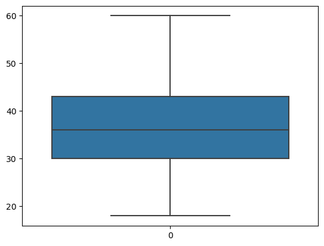

```python
sns.boxplot(dataset.Age)
```

No outliers for Age

##### Outlier Detection for DailyRate

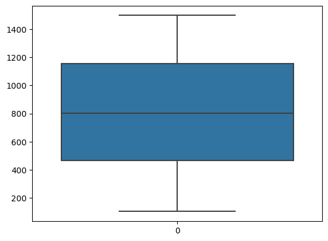

```python
sns.boxplot(dataset.DailyRate)
```

No outliers for Daily Rate

##### Outlier Detection for WorkLifeBalance

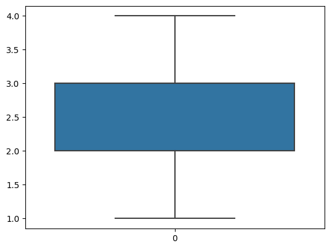

```python
sns.boxplot(dataset.WorkLifeBalance)
```

No outliers for WorkLifeBalance

## 6.Seperation of dependent and independent variables

```python
#Independent Variables
x=dataset.drop(columns=['Attrition'], inplace=False)
x
```

|  | Age | BusinessTravel | DailyRate | Department | DistanceFromHome | Education | EducationField | EmployeeCount | EmployeeNumber | EnvironmentSatisfaction | ... | RelationshipSatisfaction | StandardHours | StockOptionLevel | TotalWorkingYears | TrainingTimesLastYear | WorkLifeBalance | YearsAtCompany | YearsInCurrentRole | YearsSinceLastPromotion | YearsWithCurrManager |
| --- | --- | --- | --- | --- | --- | --- | --- | --- | --- | --- | --- | --- | --- | --- | --- | --- | --- | --- | --- | --- | --- |
| 0 | 41 | Travel_Rarely | 1102 | Sales | 1 | 2 | Life Sciences | 1 | 1 | 2 | ... | 1 | 80 | 0 | 8 | 0 | 1 | 6 | 4 | 0 | 5 |
| 1 | 49 | Travel_Frequently | 279 | Research & Development | 8 | 1 | Life Sciences | 1 | 2 | 3 | ... | 4 | 80 | 1 | 10 | 3 | 3 | 10 | 7 | 1 | 7 |
| 2 | 37 | Travel_Rarely | 1373 | Research & Development | 2 | 2 | Other | 1 | 4 | 4 | ... | 2 | 80 | 0 | 7 | 3 | 3 | 0 | 0 | 0 | 0 |
| 3 | 33 | Travel_Frequently | 1392 | Research & Development | 3 | 4 | Life Sciences | 1 | 5 | 4 | ... | 3 | 80 | 0 | 8 | 3 | 3 | 8 | 7 | 3 | 0 |
| 4 | 27 | Travel_Rarely | 591 | Research & Development | 2 | 1 | Medical | 1 | 7 | 1 | ... | 4 | 80 | 1 | 6 | 3 | 3 | 2 | 2 | 2 | 2 |
| ... | ... | ... | ... | ... | ... | ... | ... | ... | ... | ... | ... | ... | ... | ... | ... | ... | ... | ... | ... | ... | ... |
| 1465 | 36 | Travel_Frequently | 884 | Research & Development | 23 | 2 | Medical | 1 | 2061 | 3 | ... | 3 | 80 | 1 | 17 | 3 | 3 | 5 | 2 | 0 | 3 |
| 1466 | 39 | Travel_Rarely | 613 | Research & Development | 6 | 1 | Medical | 1 | 2062 | 4 | ... | 1 | 80 | 1 | 9 | 5 | 3 | 7 | 7 | 1 | 7 |
| 1467 | 27 | Travel_Rarely | 155 | Research & Development | 4 | 3 | Life Sciences | 1 | 2064 | 2 | ... | 2 | 80 | 1 | 6 | 0 | 3 | 6 | 2 | 0 | 3 |
| 1468 | 49 | Travel_Frequently | 1023 | Sales | 2 | 3 | Medical | 1 | 2065 | 4 | ... | 4 | 80 | 0 | 17 | 3 | 2 | 9 | 6 | 0 | 8 |
| 1469 | 34 | Travel_Rarely | 628 | Research & Development | 8 | 3 | Medical | 1 | 2068 | 2 | ... | 1 | 80 | 0 | 6 | 3 | 4 | 4 | 3 | 1 | 2 |

1470 rows × 34 columns

```python
x.head()
```

|  | Age | BusinessTravel | DailyRate | Department | DistanceFromHome | Education | EducationField | EmployeeCount | EmployeeNumber | EnvironmentSatisfaction | ... | RelationshipSatisfaction | StandardHours | StockOptionLevel | TotalWorkingYears | TrainingTimesLastYear | WorkLifeBalance | YearsAtCompany | YearsInCurrentRole | YearsSinceLastPromotion | YearsWithCurrManager |
| --- | --- | --- | --- | --- | --- | --- | --- | --- | --- | --- | --- | --- | --- | --- | --- | --- | --- | --- | --- | --- | --- |
| 0 | 41 | Travel_Rarely | 1102 | Sales | 1 | 2 | Life Sciences | 1 | 1 | 2 | ... | 1 | 80 | 0 | 8 | 0 | 1 | 6 | 4 | 0 | 5 |
| 1 | 49 | Travel_Frequently | 279 | Research & Development | 8 | 1 | Life Sciences | 1 | 2 | 3 | ... | 4 | 80 | 1 | 10 | 3 | 3 | 10 | 7 | 1 | 7 |
| 2 | 37 | Travel_Rarely | 1373 | Research & Development | 2 | 2 | Other | 1 | 4 | 4 | ... | 2 | 80 | 0 | 7 | 3 | 3 | 0 | 0 | 0 | 0 |
| 3 | 33 | Travel_Frequently | 1392 | Research & Development | 3 | 4 | Life Sciences | 1 | 5 | 4 | ... | 3 | 80 | 0 | 8 | 3 | 3 | 8 | 7 | 3 | 0 |
| 4 | 27 | Travel_Rarely | 591 | Research & Development | 2 | 1 | Medical | 1 | 7 | 1 | ... | 4 | 80 | 1 | 6 | 3 | 3 | 2 | 2 | 2 | 2 |

5 rows × 34 columns

```python
#Dependent variable
y=dataset.iloc[:,1:2]
```

```python
y
```

|  | Attrition |
| --- | --- |
| 0 | Yes |
| 1 | No |
| 2 | Yes |
| 3 | No |
| 4 | No |
| ... | ... |
| 1465 | No |
| 1466 | No |
| 1467 | No |
| 1468 | No |
| 1469 | No |

1470 rows × 1 columns

```python
dataset.shape
```

```
(1470, 35)
```

```python
x.shape
```

```
(1470, 34)
```

```python
y.shape
```

```
(1470, 1)
```

## 7.Encoding

Convert the strings into numerical or binary format

1.Nominal Encoding :If varaible is not worried the about arrangement of data i)one hot encoding ii)one hot encoding with many categorical variables iii)mean encoding

2.Ordinal Encoding : Take care about the rank of the data i)label encoding ii)Target guided ordinal encoding

```python
dataset.info()
```

```
<class 'pandas.core.frame.DataFrame'>
RangeIndex: 1470 entries, 0 to 1469
Data columns (total 35 columns):
 #   Column                    Non-Null Count  Dtype
---  ------                    --------------  -----
 0   Age                       1470 non-null   int64
 1   Attrition                 1470 non-null   object
 2   BusinessTravel            1470 non-null   object
 3   DailyRate                 1470 non-null   int64
 4   Department                1470 non-null   object
 5   DistanceFromHome          1470 non-null   int64
 6   Education                 1470 non-null   int64
 7   EducationField            1470 non-null   object
 8   EmployeeCount             1470 non-null   int64
 9   EmployeeNumber            1470 non-null   int64
```

[output cut: 27 more lines]

##### Label Encoding on BusinessTravel

```python
from sklearn.preprocessing import LabelEncoder
```

```python
l=LabelEncoder()
```

```python
x.BusinessTravel=l.fit_transform(x.BusinessTravel)
x["BusinessTravel"]
```

```
0       2
1       1
2       2
3       1
4       2
       ..
1465    1
1466    2
1467    2
1468    1
1469    2
Name: BusinessTravel, Length: 1470, dtype: int32
```

```python
x
```

|  | Age | BusinessTravel | DailyRate | Department | DistanceFromHome | Education | EducationField | EmployeeCount | EmployeeNumber | EnvironmentSatisfaction | ... | RelationshipSatisfaction | StandardHours | StockOptionLevel | TotalWorkingYears | TrainingTimesLastYear | WorkLifeBalance | YearsAtCompany | YearsInCurrentRole | YearsSinceLastPromotion | YearsWithCurrManager |
| --- | --- | --- | --- | --- | --- | --- | --- | --- | --- | --- | --- | --- | --- | --- | --- | --- | --- | --- | --- | --- | --- |
| 0 | 41 | 2 | 1102 | Sales | 1 | 2 | Life Sciences | 1 | 1 | 2 | ... | 1 | 80 | 0 | 8 | 0 | 1 | 6 | 4 | 0 | 5 |
| 1 | 49 | 1 | 279 | Research & Development | 8 | 1 | Life Sciences | 1 | 2 | 3 | ... | 4 | 80 | 1 | 10 | 3 | 3 | 10 | 7 | 1 | 7 |
| 2 | 37 | 2 | 1373 | Research & Development | 2 | 2 | Other | 1 | 4 | 4 | ... | 2 | 80 | 0 | 7 | 3 | 3 | 0 | 0 | 0 | 0 |
| 3 | 33 | 1 | 1392 | Research & Development | 3 | 4 | Life Sciences | 1 | 5 | 4 | ... | 3 | 80 | 0 | 8 | 3 | 3 | 8 | 7 | 3 | 0 |
| 4 | 27 | 2 | 591 | Research & Development | 2 | 1 | Medical | 1 | 7 | 1 | ... | 4 | 80 | 1 | 6 | 3 | 3 | 2 | 2 | 2 | 2 |
| ... | ... | ... | ... | ... | ... | ... | ... | ... | ... | ... | ... | ... | ... | ... | ... | ... | ... | ... | ... | ... | ... |
| 1465 | 36 | 1 | 884 | Research & Development | 23 | 2 | Medical | 1 | 2061 | 3 | ... | 3 | 80 | 1 | 17 | 3 | 3 | 5 | 2 | 0 | 3 |
| 1466 | 39 | 2 | 613 | Research & Development | 6 | 1 | Medical | 1 | 2062 | 4 | ... | 1 | 80 | 1 | 9 | 5 | 3 | 7 | 7 | 1 | 7 |
| 1467 | 27 | 2 | 155 | Research & Development | 4 | 3 | Life Sciences | 1 | 2064 | 2 | ... | 2 | 80 | 1 | 6 | 0 | 3 | 6 | 2 | 0 | 3 |
| 1468 | 49 | 1 | 1023 | Sales | 2 | 3 | Medical | 1 | 2065 | 4 | ... | 4 | 80 | 0 | 17 | 3 | 2 | 9 | 6 | 0 | 8 |
| 1469 | 34 | 2 | 628 | Research & Development | 8 | 3 | Medical | 1 | 2068 | 2 | ... | 1 | 80 | 0 | 6 | 3 | 4 | 4 | 3 | 1 | 2 |

1470 rows × 34 columns

```python
x["BusinessTravel"].value_counts()
```

```
2    1043
1     277
0     150
Name: BusinessTravel, dtype: int64
```

##### Label Encoding on Department

```python
x.Department=l.fit_transform(x.Department)
x["Department"]
```

```
0       2
1       1
2       1
3       1
4       1
       ..
1465    1
1466    1
1467    1
1468    2
1469    1
Name: Department, Length: 1470, dtype: int32
```

```python
x["Department"].value_counts()
```

```
1    961
2    446
0     63
Name: Department, dtype: int64
```

##### Label Encoding on EducationField

```python
x.EducationField=l.fit_transform(x.EducationField)
x["EducationField"]
```

```
0       1
1       1
2       4
3       1
4       3
       ..
1465    3
1466    3
1467    1
1468    3
1469    3
Name: EducationField, Length: 1470, dtype: int32
```

```python
x["EducationField"].value_counts()
```

```
1    606
3    464
2    159
5    132
4     82
0     27
Name: EducationField, dtype: int64
```

```python
x
```

|  | Age | BusinessTravel | DailyRate | Department | DistanceFromHome | Education | EducationField | EmployeeCount | EmployeeNumber | EnvironmentSatisfaction | ... | RelationshipSatisfaction | StandardHours | StockOptionLevel | TotalWorkingYears | TrainingTimesLastYear | WorkLifeBalance | YearsAtCompany | YearsInCurrentRole | YearsSinceLastPromotion | YearsWithCurrManager |
| --- | --- | --- | --- | --- | --- | --- | --- | --- | --- | --- | --- | --- | --- | --- | --- | --- | --- | --- | --- | --- | --- |
| 0 | 41 | 2 | 1102 | 2 | 1 | 2 | 1 | 1 | 1 | 2 | ... | 1 | 80 | 0 | 8 | 0 | 1 | 6 | 4 | 0 | 5 |
| 1 | 49 | 1 | 279 | 1 | 8 | 1 | 1 | 1 | 2 | 3 | ... | 4 | 80 | 1 | 10 | 3 | 3 | 10 | 7 | 1 | 7 |
| 2 | 37 | 2 | 1373 | 1 | 2 | 2 | 4 | 1 | 4 | 4 | ... | 2 | 80 | 0 | 7 | 3 | 3 | 0 | 0 | 0 | 0 |
| 3 | 33 | 1 | 1392 | 1 | 3 | 4 | 1 | 1 | 5 | 4 | ... | 3 | 80 | 0 | 8 | 3 | 3 | 8 | 7 | 3 | 0 |
| 4 | 27 | 2 | 591 | 1 | 2 | 1 | 3 | 1 | 7 | 1 | ... | 4 | 80 | 1 | 6 | 3 | 3 | 2 | 2 | 2 | 2 |
| ... | ... | ... | ... | ... | ... | ... | ... | ... | ... | ... | ... | ... | ... | ... | ... | ... | ... | ... | ... | ... | ... |
| 1465 | 36 | 1 | 884 | 1 | 23 | 2 | 3 | 1 | 2061 | 3 | ... | 3 | 80 | 1 | 17 | 3 | 3 | 5 | 2 | 0 | 3 |
| 1466 | 39 | 2 | 613 | 1 | 6 | 1 | 3 | 1 | 2062 | 4 | ... | 1 | 80 | 1 | 9 | 5 | 3 | 7 | 7 | 1 | 7 |
| 1467 | 27 | 2 | 155 | 1 | 4 | 3 | 1 | 1 | 2064 | 2 | ... | 2 | 80 | 1 | 6 | 0 | 3 | 6 | 2 | 0 | 3 |
| 1468 | 49 | 1 | 1023 | 2 | 2 | 3 | 3 | 1 | 2065 | 4 | ... | 4 | 80 | 0 | 17 | 3 | 2 | 9 | 6 | 0 | 8 |
| 1469 | 34 | 2 | 628 | 1 | 8 | 3 | 3 | 1 | 2068 | 2 | ... | 1 | 80 | 0 | 6 | 3 | 4 | 4 | 3 | 1 | 2 |

1470 rows × 34 columns

##### Label Encoding on Gender,JobRole,MaritalStatus,Over18 & OverTime

```python
# Label Encoding on Gender
x.Gender=l.fit_transform(x.Gender)
x["Gender"]
```

```
0       0
1       1
2       1
3       0
4       1
       ..
1465    1
1466    1
1467    1
1468    1
1469    1
Name: Gender, Length: 1470, dtype: int32
```

```python
#Label Encoding on JobRole
x.JobRole=l.fit_transform(x.JobRole)
x["JobRole"]
```

```
0       7
1       6
2       2
3       6
4       2
       ..
1465    2
1466    0
1467    4
1468    7
1469    2
Name: JobRole, Length: 1470, dtype: int32
```

```python
#Label Encoding on MaritalStatus
x.MaritalStatus=l.fit_transform(x.MaritalStatus)
x["MaritalStatus"]
```

```
0       2
1       1
2       2
3       1
4       1
       ..
1465    1
1466    1
1467    1
1468    1
1469    1
Name: MaritalStatus, Length: 1470, dtype: int32
```

```python
#Label Encoding on Over18
x.Over18=l.fit_transform(x.Over18)
x["Over18"]
```

```
0       0
1       0
2       0
3       0
4       0
       ..
1465    0
1466    0
1467    0
1468    0
1469    0
Name: Over18, Length: 1470, dtype: int32
```

```python
#Label Encoding on OverTime
x.OverTime=l.fit_transform(x.OverTime)
x["OverTime"]
```

```
0       1
1       0
2       1
3       1
4       0
       ..
1465    0
1466    0
1467    1
1468    0
1469    0
Name: OverTime, Length: 1470, dtype: int32
```

```python
x
```

|  | Age | BusinessTravel | DailyRate | Department | DistanceFromHome | Education | EducationField | EmployeeCount | EmployeeNumber | EnvironmentSatisfaction | ... | RelationshipSatisfaction | StandardHours | StockOptionLevel | TotalWorkingYears | TrainingTimesLastYear | WorkLifeBalance | YearsAtCompany | YearsInCurrentRole | YearsSinceLastPromotion | YearsWithCurrManager |
| --- | --- | --- | --- | --- | --- | --- | --- | --- | --- | --- | --- | --- | --- | --- | --- | --- | --- | --- | --- | --- | --- |
| 0 | 41 | 2 | 1102 | 2 | 1 | 2 | 1 | 1 | 1 | 2 | ... | 1 | 80 | 0 | 8 | 0 | 1 | 6 | 4 | 0 | 5 |
| 1 | 49 | 1 | 279 | 1 | 8 | 1 | 1 | 1 | 2 | 3 | ... | 4 | 80 | 1 | 10 | 3 | 3 | 10 | 7 | 1 | 7 |
| 2 | 37 | 2 | 1373 | 1 | 2 | 2 | 4 | 1 | 4 | 4 | ... | 2 | 80 | 0 | 7 | 3 | 3 | 0 | 0 | 0 | 0 |
| 3 | 33 | 1 | 1392 | 1 | 3 | 4 | 1 | 1 | 5 | 4 | ... | 3 | 80 | 0 | 8 | 3 | 3 | 8 | 7 | 3 | 0 |
| 4 | 27 | 2 | 591 | 1 | 2 | 1 | 3 | 1 | 7 | 1 | ... | 4 | 80 | 1 | 6 | 3 | 3 | 2 | 2 | 2 | 2 |
| ... | ... | ... | ... | ... | ... | ... | ... | ... | ... | ... | ... | ... | ... | ... | ... | ... | ... | ... | ... | ... | ... |
| 1465 | 36 | 1 | 884 | 1 | 23 | 2 | 3 | 1 | 2061 | 3 | ... | 3 | 80 | 1 | 17 | 3 | 3 | 5 | 2 | 0 | 3 |
| 1466 | 39 | 2 | 613 | 1 | 6 | 1 | 3 | 1 | 2062 | 4 | ... | 1 | 80 | 1 | 9 | 5 | 3 | 7 | 7 | 1 | 7 |
| 1467 | 27 | 2 | 155 | 1 | 4 | 3 | 1 | 1 | 2064 | 2 | ... | 2 | 80 | 1 | 6 | 0 | 3 | 6 | 2 | 0 | 3 |
| 1468 | 49 | 1 | 1023 | 2 | 2 | 3 | 3 | 1 | 2065 | 4 | ... | 4 | 80 | 0 | 17 | 3 | 2 | 9 | 6 | 0 | 8 |
| 1469 | 34 | 2 | 628 | 1 | 8 | 3 | 3 | 1 | 2068 | 2 | ... | 1 | 80 | 0 | 6 | 3 | 4 | 4 | 3 | 1 | 2 |

1470 rows × 34 columns

##### Label encoding on Dependent Variable Attrition

```python
#Label Encoding on Attrition
y["Attrition"]=l.fit_transform(y.Attrition)
y["Attrition"]
```

```
0       1
1       0
2       1
3       0
4       0
       ..
1465    0
1466    0
1467    0
1468    0
1469    0
Name: Attrition, Length: 1470, dtype: int32
```

We have training and testting data

example: 1000 rows

Training data : 70%-80%

Testing data : 20%-30% (checking performance)

### Correlation after encoding

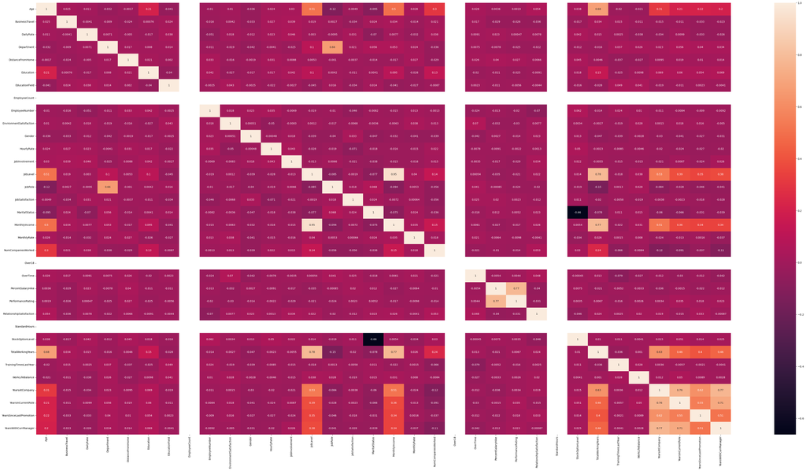

```python
corr = x.corr()
plt.subplots(figsize=(60,30))
sns.heatmap(corr,annot=True)
```

## 9.Feature Scaling

```python
from sklearn.preprocessing import MinMaxScaler
ms=MinMaxScaler()
x_scaled=pd.DataFrame(ms.fit_transform(x),columns=x.columns)
```

```python
x_scaled
```

|  | Age | BusinessTravel | DailyRate | Department | DistanceFromHome | Education | EducationField | EmployeeCount | EmployeeNumber | EnvironmentSatisfaction | ... | RelationshipSatisfaction | StandardHours | StockOptionLevel | TotalWorkingYears | TrainingTimesLastYear | WorkLifeBalance | YearsAtCompany | YearsInCurrentRole | YearsSinceLastPromotion | YearsWithCurrManager |
| --- | --- | --- | --- | --- | --- | --- | --- | --- | --- | --- | --- | --- | --- | --- | --- | --- | --- | --- | --- | --- | --- |
| 0 | 0.547619 | 1.0 | 0.715820 | 1.0 | 0.000000 | 0.25 | 0.2 | 0.0 | 0.000000 | 0.333333 | ... | 0.000000 | 0.0 | 0.000000 | 0.200 | 0.000000 | 0.000000 | 0.150 | 0.222222 | 0.000000 | 0.294118 |
| 1 | 0.738095 | 0.5 | 0.126700 | 0.5 | 0.250000 | 0.00 | 0.2 | 0.0 | 0.000484 | 0.666667 | ... | 1.000000 | 0.0 | 0.333333 | 0.250 | 0.500000 | 0.666667 | 0.250 | 0.388889 | 0.066667 | 0.411765 |
| 2 | 0.452381 | 1.0 | 0.909807 | 0.5 | 0.035714 | 0.25 | 0.8 | 0.0 | 0.001451 | 1.000000 | ... | 0.333333 | 0.0 | 0.000000 | 0.175 | 0.500000 | 0.666667 | 0.000 | 0.000000 | 0.000000 | 0.000000 |
| 3 | 0.357143 | 0.5 | 0.923407 | 0.5 | 0.071429 | 0.75 | 0.2 | 0.0 | 0.001935 | 1.000000 | ... | 0.666667 | 0.0 | 0.000000 | 0.200 | 0.500000 | 0.666667 | 0.200 | 0.388889 | 0.200000 | 0.000000 |
| 4 | 0.214286 | 1.0 | 0.350036 | 0.5 | 0.035714 | 0.00 | 0.6 | 0.0 | 0.002903 | 0.000000 | ... | 1.000000 | 0.0 | 0.333333 | 0.150 | 0.500000 | 0.666667 | 0.050 | 0.111111 | 0.133333 | 0.117647 |
| ... | ... | ... | ... | ... | ... | ... | ... | ... | ... | ... | ... | ... | ... | ... | ... | ... | ... | ... | ... | ... | ... |
| 1465 | 0.428571 | 0.5 | 0.559771 | 0.5 | 0.785714 | 0.25 | 0.6 | 0.0 | 0.996613 | 0.666667 | ... | 0.666667 | 0.0 | 0.333333 | 0.425 | 0.500000 | 0.666667 | 0.125 | 0.111111 | 0.000000 | 0.176471 |
| 1466 | 0.500000 | 1.0 | 0.365784 | 0.5 | 0.178571 | 0.00 | 0.6 | 0.0 | 0.997097 | 1.000000 | ... | 0.000000 | 0.0 | 0.333333 | 0.225 | 0.833333 | 0.666667 | 0.175 | 0.388889 | 0.066667 | 0.411765 |
| 1467 | 0.214286 | 1.0 | 0.037938 | 0.5 | 0.107143 | 0.50 | 0.2 | 0.0 | 0.998065 | 0.333333 | ... | 0.333333 | 0.0 | 0.333333 | 0.150 | 0.000000 | 0.666667 | 0.150 | 0.111111 | 0.000000 | 0.176471 |
| 1468 | 0.738095 | 0.5 | 0.659270 | 1.0 | 0.035714 | 0.50 | 0.6 | 0.0 | 0.998549 | 1.000000 | ... | 1.000000 | 0.0 | 0.000000 | 0.425 | 0.500000 | 0.333333 | 0.225 | 0.333333 | 0.000000 | 0.470588 |
| 1469 | 0.380952 | 1.0 | 0.376521 | 0.5 | 0.250000 | 0.50 | 0.6 | 0.0 | 1.000000 | 0.333333 | ... | 0.000000 | 0.0 | 0.000000 | 0.150 | 0.500000 | 1.000000 | 0.100 | 0.166667 | 0.066667 | 0.117647 |

1470 rows × 34 columns

## 8.Splitting into training set and testing set

```python
from sklearn.model_selection import train_test_split
x_train,x_test,y_train,y_test=train_test_split(x_scaled,y,test_size=0.2,random_state=0)
```

```python
x_train.shape,x_test.shape,y_train.shape,y_test.shape
```

```
((1176, 34), (294, 34), (1176, 1), (294, 1))
```

```python
x_train.head()
```

|  | Age | BusinessTravel | DailyRate | Department | DistanceFromHome | Education | EducationField | EmployeeCount | EmployeeNumber | EnvironmentSatisfaction | ... | RelationshipSatisfaction | StandardHours | StockOptionLevel | TotalWorkingYears | TrainingTimesLastYear | WorkLifeBalance | YearsAtCompany | YearsInCurrentRole | YearsSinceLastPromotion | YearsWithCurrManager |
| --- | --- | --- | --- | --- | --- | --- | --- | --- | --- | --- | --- | --- | --- | --- | --- | --- | --- | --- | --- | --- | --- |
| 1374 | 0.952381 | 1.0 | 0.360057 | 1.0 | 0.714286 | 0.50 | 0.2 | 0.0 | 0.937107 | 1.000000 | ... | 0.666667 | 0.0 | 0.333333 | 0.725 | 0.333333 | 0.333333 | 0.025 | 0.000000 | 0.000000 | 0.000000 |
| 1092 | 0.642857 | 1.0 | 0.607015 | 0.5 | 0.964286 | 0.50 | 1.0 | 0.0 | 0.747460 | 1.000000 | ... | 1.000000 | 0.0 | 0.333333 | 0.200 | 0.500000 | 0.666667 | 0.125 | 0.222222 | 0.000000 | 0.176471 |
| 768 | 0.523810 | 1.0 | 0.141732 | 1.0 | 0.892857 | 0.50 | 0.4 | 0.0 | 0.515239 | 0.666667 | ... | 0.333333 | 0.0 | 0.333333 | 0.200 | 0.500000 | 0.333333 | 0.175 | 0.388889 | 0.466667 | 0.294118 |
| 569 | 0.428571 | 0.0 | 0.953472 | 1.0 | 0.250000 | 0.75 | 0.2 | 0.0 | 0.381229 | 0.000000 | ... | 0.333333 | 0.0 | 0.000000 | 0.250 | 0.166667 | 0.666667 | 0.250 | 0.388889 | 0.000000 | 0.529412 |
| 911 | 0.166667 | 0.5 | 0.355762 | 1.0 | 0.821429 | 0.00 | 0.2 | 0.0 | 0.615385 | 0.666667 | ... | 1.000000 | 0.0 | 0.000000 | 0.025 | 0.666667 | 0.666667 | 0.025 | 0.000000 | 0.066667 | 0.000000 |

5 rows × 34 columns

```python
x_test
```

[output not shown]

294 rows × 34 columns

```python
y_train
```

|  | Attrition |
| --- | --- |
| 1374 | 0 |
| 1092 | 0 |
| 768 | 0 |
| 569 | 0 |
| 911 | 1 |
| ... | ... |
| 763 | 0 |
| 835 | 0 |
| 1216 | 0 |
| 559 | 0 |
| 684 | 0 |

1176 rows × 1 columns

```python
y_test
```

|  | Attrition |
| --- | --- |
| 442 | 0 |
| 1091 | 0 |
| 981 | 1 |
| 785 | 0 |
| 1332 | 1 |
| ... | ... |
| 1439 | 0 |
| 481 | 0 |
| 124 | 1 |
| 198 | 0 |
| 1229 | 0 |

294 rows × 1 columns